# Open Street Map Project - Analysis of Whittier, CA OSM Data

## By Jacob Dodd

### Background

For my Data Analyst Nanodegree (https://www.udacity.com/course/data-analyst-nanodegree--nd002), I was tasked with extracting data from Open Street Map (https://www.openstreetmap.org/), and auditing, cleaning, and loading it into a SQLite database for analysis.

I was able to accomplish this via Python scripts that ran through the extracted xml files and then audited and cleaned them into csv files. The csvs were then loaded into a sqlite database, where I ran queries analyzing the data.

## Map Area: Whittier, CA

My hometown!

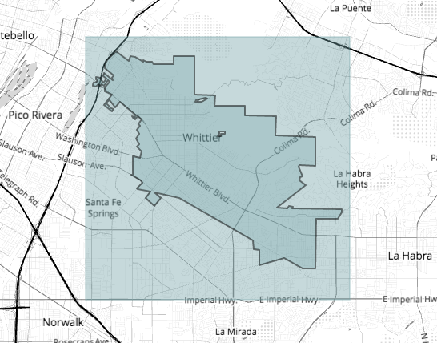

```python
from IPython.display import Image
Image("whittiermap.png")
```

Above is the custom extract from the Mapzen API. Whittier is an LA area suburb of ~85K people, teetering on the border of LA and Orange Counties. I am interested in seeing what the data reveals, and hopefully clean up some problems in the dataset.

The reason for for the bounding I chose was that I wanted to include the area to the lower left of the box, "South Whittier", an un-incorporated area (LA County) that most Whittier-ites would count as Whittier.

- https://en.wikipedia.org/wiki/Whittier,_California

## Problems Encountered

**Road Auditing**

```python
"""
{'A': set(['Carmenita Rd #A', 'Hadley Street Suite A']),
 'Blvd': set(['South Hacienda Blvd', 'Whittier Blvd']),
 'Rd': set(['Telegraph Rd'])}
Whittier Blvd => Whittier Boulevard
South Hacienda Blvd => South Hacienda Boulevard
Carmenita Rd #A => Carmenita Road
Hadley Street Suite A => Hadley Street
Telegraph Rd => Telegraph Road
"""
```

Most of the Road Data was surprisingly clean. There were some exceptions:

- Road names ending with address ("Suite A")
- Blvd and Rd abbreviations

These were both easy fixes, with some updating of my update name function and my mapping dictionary.

**Descrepencies with Zip Codes and Street Names**

```python
	<way changeset="13017994" id="13335265" timestamp="2012-09-07T02:30:42Z" uid="358440" user="russdeffner" version="6">
		<nd ref="122770749" />
		<nd ref="1903424070" />
		<nd ref="1903424092" />
		<nd ref="1903424185" />
		<nd ref="1903424179" />
		<nd ref="1903424064" />
		<nd ref="1903424052" />
		<nd ref="1903424047" />
		<nd ref="1903424038" />
		<nd ref="1903424159" />
		<nd ref="1903424113" />
		<nd ref="1903424149" />
		<nd ref="1903424147" />
		<nd ref="1903424161" />
		<nd ref="1903424170" />
		<nd ref="1903424130" />
		<nd ref="1903424134" />
		<nd ref="1903424044" />
		<tag k="name" v="Pine Bluff Drive" />
		<tag k="highway" v="residential" />
		<tag k="tiger:cfcc" v="A41" />
		<tag k="tiger:tlid" v="141775327" />
		<tag k="tiger:county" v="Los Angeles, CA" />
		<tag k="tiger:source" v="tiger_import_dch_v0.6_20070809" />
		<tag k="tiger:zip_left" v="90601" />
		<tag k="tiger:name_base" v="Pine Bluff" />
		<tag k="tiger:name_type" v="Dr" />
		<tag k="tiger:separated" v="no" />
		<tag k="tiger:zip_right" v="90601" />
	</way>
```

1) Street Names

Names imported from Tiger GPS had street names divided between 'name_base' and 'name_type'.

2) Zips

Some of the ways files, like the example above, had both a "zip_left" and "zip_right" tag, so determining the zip code could be difficult. I queried both and compared the results.

Knowing that the elements that contained one contained the other one of these tags, I am simply looking for unusual zip codes.

```python
sqlite> SELECT tags.value, COUNT(*) as sum
   ...> FROM (SELECT * FROM nodes_tags
   ...> UNION ALL
   ...> SELECT * FROM ways_tags) tags
   ...> WHERE tags.key='zip_left'
   ...> GROUP BY tags.value
   ...> ORDER BY sum DESC;

sqlite> SELECT tags.value, COUNT(*) as sum
   ...> FROM (SELECT * FROM nodes_tags
   ...> UNION ALL
   ...> SELECT * FROM ways_tags) tags
   ...> WHERE tags.key='zip_right'
   ...> GROUP BY tags.value
   ...> ORDER BY sum DESC;
```

```python
ZIP LEFT

90604|573
90603|506
91745|408
90606|337
90605|336
90601|322
90631|235
90638|187
90602|159
90670|128
90660|49
90602:90605|47
90650|33
90608|3

ZIP RIGHT

90604|593
90603|501
91745|401
90605|334
90601|321
90606|317
90631|233
90602|179
90638|159
90670|112
90660|50
90602:90605|47
90650|33
91744|3
90608|1
```

For the most part, these are accurate!

- 90604, 90603 are Whittier, while 91745 is Hacienda Heights (east of Whittier)

## File Overview and Statistics

### File Sizes

- whittier.osm ....... 210.4 MB
- whittier_osm.db ....... 118.8 MB
- nodes.csv ...... 86.4 MB
- ways_nodes.csv ...... 24.5 MB
- ways_tags.csv ...... 19.5
- ways.csv ...... 6.2 MB
- nodes_tags.csv ...... 128 KB

### Unique Users

```python
sqlite> SELECT COUNT(DISTINCT(users.uid))
   ...> FROM (SELECT uid FROM nodes UNION ALL
   ...> SELECT uid FROM ways) users;
```

```python
209
```

There are 209 unique users that contributed to the nodes or ways elements in this file.

### Number of Nodes

```python
sqlite> SELECT COUNT(*) FROM nodes;
```

```python
914475
```

### Number of Ways

```python
sqlite> SELECT COUNT(*) FROM ways;
```

```python
89337
```

### Top Node Keys

```python
sqlite> SELECT key, COUNT(key) as count
   ...> FROM nodes_tags
   ...> GROUP BY key
   ...> ORDER BY count DESC
   ...> LIMIT 20;
```

```python
highway|912
power|504
name|223
amenity|165
ele|157
feature_id|145
county_id|136
created|136
state_id|136
odbl|79
source|62
religion|58
natural|48
edited|40
railway|38
type|37
structure|35
design|34
material|34
housenumber|26
```

### Top Ways Keys

```python
sqlite> SELECT key, COUNT(key) as count
   ...> FROM ways_tags
   ...> GROUP BY key
   ...> ORDER BY count DESC
   ...> LIMIT 20;
```

```python
building,80816
ele,77109
bld_id,77080
height,77080
ain,77079
start_date,75092
units,71678
highway,6831
name,4805
county,3472
cfcc,3444
name_base,3415
name_type,3357
zip_left,3323
zip_right,3284
source,2218
lanes,2079
tlid,1526
separated,1521
oneway,1335
```

### Top 15 Users who Contributed

```python
sqlite> SELECT users.user, COUNT(*) as total
   ...> FROM (SELECT user FROM nodes UNION ALL
   ...> SELECT user FROM ways) users
   ...> GROUP BY users.user
   ...> ORDER BY total DESC
   ...> LIMIT 15;
```

```python
calfarome_labuilding|210673
yurasi_import|173569
piligab_labuildings|129035
RichRico_labuildings|121388
ridixcr_import|91900
manoharuss_imports|71383
Jothirnadh_labuildings|68547
dannykath_labuildings|44361
karitotp_labuildings|36681
Luis36995_labuildings|10214
Rockear|4535
Brian@Brea|3653
manings_labuildings|3485
Christine_E|2611
RichRico|2510
```

The "_labuildings" at the end of some these top users makes me wonder if there was a "LA Buildings" mapathon or maybe some GIS interns at LA County were tasked with doing this, which would explain why many of these are in the top 10. We can look at the date contributed to verify this.

### Top Amenities

```python
sqlite> SELECT tags.value, COUNT(*) as sum
   ...> FROM (SELECT * FROM nodes_tags
   ...> UNION ALL
   ...> SELECT * FROM ways_tags) tags
   ...> WHERE tags.key='amenity'
   ...> GROUP BY tags.value
   ...> ORDER BY sum DESC;
```

```python
parking|147
school|84
place_of_worship|74
grave_yard|33
fast_food|16
fuel|13
toilets|9
restaurant|7
fire_station|6
clinic|5
library|5
social_facility|5
hospital|4
community_centre|3
fountain|3
bank|2
pharmacy|2
post_office|2
theatre|2
atm|1
bus_station|1
college|1
courthouse|1
doctors|1
drinking_water|1
post_box|1
townhall|1
```

33 Nodes with an Amenity value of Graveyard? No doubt these must be referring to Rose Hills, a large Memorial Park in the hills North of Whittier. 74 Places of Worship sound accurate as well. In the nodes keys, some values were religious. Let's take a closer look there.

### Most Popular Religions

I would expect some sort of Christianity to be at the top here. There is a large amount of Christian and Catholic churches in the area.

```python
sqlite> SELECT value, COUNT(*) as sum
   ...> FROM nodes_tags
   ...> WHERE key = 'religion'
   ...> GROUP BY value
   ...> ;
```

```python
christian|57
jewish|1
```

Not much here. As predicted, christianity is the most popular religion, though I wonder if Catholic is lumped in with that.

### State Id

This was another large node_tag key value. I would predict all will be one value.

```python
sqlite> SELECT value, COUNT(*) as sum
   ...> FROM nodes_tags
   ...> WHERE key = 'state_id'
   ...> GROUP BY value
   ...> ;
```

```python
06|136
```

Good! The state id value is the same for each node with state_id. There is only one state in the Map area (CA).

## Suggestions and Discussion

### Most of the Data added by "_labuildings" and "_imports" Users

As a result, the amenities values were lacking, with many not being resteraunts, or other features of the urban landscape.

The lack of diversity in the users uploading information led to a lack of diversity in the nodes and ways elements.

There needs to be a larger diversity of users who add information for their to be more descriptive info.

### Possible Improvements

One potential trove of data is Pokestop data from the PokemonGO mobile video game. This game uses your geographic location as a map, and there are "Pokestops", which represent real-life points of interest where you can get items. Think of Pokestops as nodes!

Benefits:

1) The pokestop data is probably in a similar format as nodes/tags data. There are lat/long, timestamp, id, which are the main components that could be easily appended

2) Add diversity of nodes tags- the fact that pokestops are anything from interesting buildings to murals to businesses will add a great deal of diversity in the key values. This will give a more complete picture of the city, at least from a cultural or local perspective.

Drawbacks:

1) Might be hard to obtain data, depending on the quality of APIs, and legality.

2) Effort in writing script making API calls might not be worth the amount of effort required- the number of pokestops most likely will not add more than 200 rows to the nodes file.

I will end with analysis of the "highway" key values:

### Highway Key Values

```python
sqlite> SELECT value, COUNT(*) as sum
   ...> FROM nodes_tags
   ...> WHERE key='highway'
   ...> GROUP BY value;
```

```python
bus_stop|26
crossing|24
motorway_junction|7
stop|7
traffic_signals|40
turning_circle|807
turning_loop|1
```

# Conclusion

It is clear this data is still a work in progress, and outside of a select few users, there has not been much information added. However, the data that is here is relatively clean and contains a good amount of administrative information.